# Hierarchical bayesian model small area estimation in hbsaems package

## Introduction

This vignette demonstrates how to perform **Bayesian modeling for Small Area Estimation (SAE)** using the tools provided in the **`hbsaems`** package. It follows the **Bayesian workflow**, a structured approach that includes prior specification, prior predictive checks, model fitting using MCMC, convergence diagnostics, model evaluation, and prediction.

The modeling process is centered around the `hbsaems` package, which provides the following core functions to support each stage of the workflow:

- **`hbpc()`** — for **prior predictive checking**, allowing users to evaluate whether the chosen priors generate plausible data before observing the actual data.
- **`hbm()`** — for **fitting hierarchical Bayesian models**, including fixed and random effects, spatial structures, and handling of missing data. The **`hbsaems`** package includes two key functions for modeling: **`hbm()`** and **`hbm_model()`**.
  - **`hbm()`** offers greater flexibility in writing formulas but requires more familiarity with model specification and structure.
  - **`hbm_model()`**, on the other hand, is more user-friendly, designed for those who may not be familiar with writing complex formulas, offering a simpler interface for model specification.
- **`hbcc()`** — for **convergence diagnostics**, assessing whether the MCMC algorithm has properly converged using R-hat statistics, trace plots, and effective sample sizes.
- **`hbmc()`** — for **model evaluation and comparison**, including information criteria such as WAIC and LOO.
- **`hbsae()`** — for **generating predictions** at the small area level, incorporating posterior uncertainty.

By integrating these functions, this vignette provides a complete guide to modeling within a Bayesian framework, specifically tailored for SAE problems. The goal is not only to fit a model, but to ensure it is well-calibrated, interpretable, and useful for prediction.

**Small Area Estimation (SAE)** is a statistical approach used to produce reliable estimates for small geographic areas or subpopulations where direct survey estimation is limited by small sample sizes. SAE models combine survey data with auxiliary information to enhance precision and reduce the variability of estimates. This vignette provides an overview of the SAE methodology, including model formulations and implementation using the hbsaems package. The area-level model is one of the common SAE approaches, incorporating auxiliary data at the area level to improve estimation accuracy.

Bayesian SAE methods provide a flexible framework for incorporating prior information and quantifying uncertainty. Bayesian models can be specified using **Markov Chain Monte Carlo (MCMC)** methods. Bayesian methods are often used to estimate the area-level model parameters.

## Model Overview

The `hbm` function fits a hierarchical Bayesian model using the `brms` package. It supports various modeling options, including:

1. Fixed effects for covariates.
2. Random effects for spatial or hierarchical structures.
3. Spatial random effects using CAR/SAR structures.
4. Handling missing data through deletion, model-based, or multiple imputation.
5. Allows user-defined priors for model flexibility.
6. Provides model diagnostics, including convergence checks and model comparison.
7. Outputs include fitted model objects (`hbmfit`), diagnostic summaries, and predictions for small areas.

The function is designed for Small Area Estimation (SAE) applications, providing flexible modeling capabilities for analyzing complex hierarchical data.

## Simulated Data Example

```r
library(hbsaems)
data <- data_fhnorm
head(data)
```

```
#>          y         D       x1        x2       x3 theta_true          u group
#> 1 4.877812 0.2951779 3.879049  7.868780 23.79524   4.352293 -0.5057526     1
#> 2 3.429696 0.1980448 4.539645 10.770651 20.24965   3.477883 -0.5322315     2
#> 3 4.595225 0.1778341 8.117417  9.259924 13.93942   4.889751 -0.6636471     3
#> 4 3.494359 0.1835110 5.141017  8.957372 17.17278   3.612569 -0.7442393     4
#> 5 4.359012 0.1185852 5.258575  7.145144 13.34264   3.975170 -0.3091185     5
#> 6 4.828993 0.1323618 8.430130  9.864917 13.09501   4.628878  0.2341790     6
#>   sre
#> 1   1
#> 2   1
#> 3   1
#> 4   1
#> 5   1
#> 6   1
```

- `y`: the direct estimate for each area, assumed to follow a Normal distribution with known sampling variance
- `D`: the known sampling variance for each area’s direct estimate
- `x1`, `x2`, `x3`: auxiliary variables that may explain variation in the outcome
- `theta_true`: the true underlying value of the area-specific parameter (latent mean)
- `u`: the area-level random effect drawn from a normal distribution

This dataset is useful for testing and illustrating small area estimation techniques, particularly in settings where the direct estimates are continuous and modeled using a Gaussian distribution.

## Initial Model

We begin by specifying the model with informative priors on the coefficients and the intercept. The `sample_prior = "only"` argument ensures that the model ignores the data and simulates predictions based on the priors alone. This is particularly useful for performing a **prior predictive check**, which involves generating data purely from the prior distributions to evaluate whether the priors lead to plausible values of the outcome variable.

```r
model_prior_pred <- hbm(
  formula = bf(y ~ x1 + x2 + x3),
  data = data,
  hb_sampling = "gaussian",
  hb_link = "log",
  chains = 4,
  iter = 500,
  warmup = 250,
  sample_prior = "only",
  prior = c(
    prior("normal(1, 0.2)", class = "Intercept"),
    prior("normal(0, 0.1)", class = "b"),
    prior("exponential(5)", class = "sd")
  )
)
```

```
#>
#>
#>
#>
#> Warning: Bulk Effective Samples Size (ESS) is too low, indicating posterior means and medians may be unreliable.
#> Running the chains for more iterations may help. See
#> https://mc-stan.org/misc/warnings.html#bulk-ess
```

```r
summary(model_prior_pred)
```

```
#>
#> ======= Hierarchical Bayesian Model Summary (from hbmfit) =======
#>
#> --- Full brms Model Summary ---
#>  Family: gaussian
#>   Links: mu = log; sigma = identity
#> Formula: y ~ x1 + x2 + x3 + (1 | group)
#>    Data: data (Number of observations: 100)
#>   Draws: 4 chains, each with iter = 500; warmup = 250; thin = 1;
#>          total post-warmup draws = 1000
#>
#> Multilevel Hyperparameters:
#> ~group (Number of levels: 100)
#>               Estimate Est.Error l-95% CI u-95% CI Rhat Bulk_ESS Tail_ESS
#> sd(Intercept)     0.20      0.18     0.01     0.69 1.00     1163      624
#>
#> Regression Coefficients:
#>           Estimate Est.Error l-95% CI u-95% CI Rhat Bulk_ESS Tail_ESS
#> Intercept     0.95      1.89    -2.70     4.64 1.01     2160      973
#> x1            0.00      0.10    -0.20     0.19 1.00     2182      673
#> x2            0.00      0.10    -0.20     0.20 1.00     1530      616
#> x3            0.00      0.10    -0.19     0.19 1.01     2271      673
#>
#> Further Distributional Parameters:
#>       Estimate Est.Error l-95% CI u-95% CI Rhat Bulk_ESS Tail_ESS
#> sigma     2.77      3.00     0.12    10.47 1.00     1444      687
#>
#> Draws were sampled using sampling(NUTS). For each parameter, Bulk_ESS
#> and Tail_ESS are effective sample size measures, and Rhat is the potential
#> scale reduction factor on split chains (at convergence, Rhat = 1).
#>
#>
#> ===== Detailed Group-Level Effects (Random Effects) Summary =====
#>
#> --- Grouping Factor: group ---
#> The table below (in the next console output) contains group-level estimates
#> for the factor 'group', with dimensions 1 rows x 7 columns.
#>
#> Columns: Estimate, Est.Error, l-95% CI, u-95% CI, Rhat, Bulk_ESS, Tail_ESS.               Estimate Est.Error    l-95% CI  u-95% CI     Rhat Bulk_ESS
#> sd(Intercept) 0.2003475 0.1798399 0.005799299 0.6948109 1.000157 1162.986
#>               Tail_ESS
#> sd(Intercept) 624.2704
#>
#>
#> =========== Missing Data Handling (specified in hbm) ============
#> No specific missing data handling method was applied through the hbm function.
#> (brms internal defaults for NA handling in predictors/response may have applied if NAs were present and not pre-processed).
```

## Prior Predictive Check

Before fitting a Bayesian model to the data, it is important to evaluate whether the chosen priors lead to sensible predictions. This process is called a **prior predictive check**.

Prior predictive checks help to:

- Identify whether the priors are overly vague or unrealistically informative.
- Ensure that the prior assumptions do not produce unreasonable predictions before any actual data are used.
- Avoid unintentionally strong or misleading prior beliefs that could affect posterior inference.

This step is especially important in Bayesian modeling to build confidence that the model structure and prior choices are coherent before observing any data.

```r
result_hbpc <- hbpc(model_prior_pred)
```

```
#> Using 'y' as the response variable for pp_check.
```

```r
summary(result_hbpc)
```

```
#>
#> ================= Prior Predictive Check Summary =================
#>
#> -------------- Priors Used in the Model --------------
#>                 prior     class      coef group resp dpar nlpar lb ub
#>        normal(0, 0.1)         b
#>        normal(0, 0.1)         b        x1
#>        normal(0, 0.1)         b        x2
#>        normal(0, 0.1)         b        x3
#>        normal(1, 0.2) Intercept
#>        exponential(5)        sd                                  0
#>        exponential(5)        sd           group                  0
#>        exponential(5)        sd Intercept group                  0
#>  student_t(3, 0, 2.5)     sigma                                  0
#>        source
#>          user
#>  (vectorized)
#>  (vectorized)
#>  (vectorized)
#>          user
#>          user
#>  (vectorized)
#>  (vectorized)
#>       default
#>
#> ----- Summary of Parameter Draws from Prior Model -----
#>  Family: gaussian
#>   Links: mu = log; sigma = identity
#> Formula: y ~ x1 + x2 + x3 + (1 | group)
#>    Data: data (Number of observations: 100)
#>   Draws: 4 chains, each with iter = 500; warmup = 250; thin = 1;
#>          total post-warmup draws = 1000
#>
#> Multilevel Hyperparameters:
#> ~group (Number of levels: 100)
#>               Estimate Est.Error l-95% CI u-95% CI Rhat Bulk_ESS Tail_ESS
#> sd(Intercept)     0.20      0.18     0.01     0.69 1.00     1163      624
#>
#> Regression Coefficients:
#>           Estimate Est.Error l-95% CI u-95% CI Rhat Bulk_ESS Tail_ESS
#> Intercept     0.95      1.89    -2.70     4.64 1.01     2160      973
#> x1            0.00      0.10    -0.20     0.19 1.00     2182      673
#> x2            0.00      0.10    -0.20     0.20 1.00     1530      616
#> x3            0.00      0.10    -0.19     0.19 1.01     2271      673
#>
#> Further Distributional Parameters:
#>       Estimate Est.Error l-95% CI u-95% CI Rhat Bulk_ESS Tail_ESS
#> sigma     2.77      3.00     0.12    10.47 1.00     1444      687
#>
#> Draws were sampled using sampling(NUTS). For each parameter, Bulk_ESS
#> and Tail_ESS are effective sample size measures, and Rhat is the potential
#> scale reduction factor on split chains (at convergence, Rhat = 1).
#>
#> --------------- Priors Predictive Plot ----------------
#>
#> Note: The prior predictive plot is stored in '$prior_predictive_plot'.
#> This plot compares observed data (if applicable) with predictions generated solely from the priors.
```

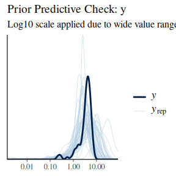

```r
result_hbpc$prior_predictive_plot
```

## Fitting the Model

After prior predictive checks confirm the priors are suitable, we proceed to fit the model using `sample_prior = "no"`. Why `sample_prior = "no"`?

- We already conducted a prior predictive check (previous explanation), `sample_prior = "no"` tells `brms` to:
  - Use the **priors** in the estimation.
  - Focus entirely on drawing from the **posterior** given the observed data.
- This option is standard for final model fitting after priors have been validated.

### 1. Basic Model

```r
model <- hbm(
  formula = bf(y ~ x1 + x2 + x3),
  data = data,
  hb_sampling = "gaussian",
  hb_link = "log",
  chains = 4,
  iter = 500,
  warmup = 250,
  sample_prior = "no",
  prior = c(
    prior("normal(1, 0.2)", class = "Intercept"),
    prior("normal(0, 0.1)", class = "b"),
    prior("exponential(5)", class = "sd")
  )
)
```

```
#>
#>
#>
#>
#> Warning: There were 3 divergent transitions after warmup. See
#> https://mc-stan.org/misc/warnings.html#divergent-transitions-after-warmup
#> to find out why this is a problem and how to eliminate them.
#> Warning: Examine the pairs() plot to diagnose sampling problems
#> Warning: Bulk Effective Samples Size (ESS) is too low, indicating posterior means and medians may be unreliable.
#> Running the chains for more iterations may help. See
#> https://mc-stan.org/misc/warnings.html#bulk-ess
#> Warning: Tail Effective Samples Size (ESS) is too low, indicating posterior variances and tail quantiles may be unreliable.
#> Running the chains for more iterations may help. See
#> https://mc-stan.org/misc/warnings.html#tail-ess
```

```r
summary(model)
```

```
#>
#> ======= Hierarchical Bayesian Model Summary (from hbmfit) =======
#>
#> --- Full brms Model Summary ---
#> Warning: There were 3 divergent transitions after warmup. Increasing
#> adapt_delta above 0.8 may help. See
#> http://mc-stan.org/misc/warnings.html#divergent-transitions-after-warmup
#>  Family: gaussian
#>   Links: mu = log; sigma = identity
#> Formula: y ~ x1 + x2 + x3 + (1 | group)
#>    Data: data (Number of observations: 100)
#>   Draws: 4 chains, each with iter = 500; warmup = 250; thin = 1;
#>          total post-warmup draws = 1000
#>
#> Multilevel Hyperparameters:
#> ~group (Number of levels: 100)
#>               Estimate Est.Error l-95% CI u-95% CI Rhat Bulk_ESS Tail_ESS
#> sd(Intercept)     0.06      0.04     0.00     0.15 1.03      194      331
#>
#> Regression Coefficients:
#>           Estimate Est.Error l-95% CI u-95% CI Rhat Bulk_ESS Tail_ESS
#> Intercept     0.88      0.15     0.59     1.18 1.00     1118      950
#> x1            0.11      0.01     0.08     0.13 1.00     1166      704
#> x2           -0.09      0.01    -0.11    -0.07 1.00     1173      693
#> x3            0.04      0.01     0.03     0.05 1.00     1135      873
#>
#> Further Distributional Parameters:
#>       Estimate Est.Error l-95% CI u-95% CI Rhat Bulk_ESS Tail_ESS
#> sigma     0.95      0.08     0.80     1.11 1.00      461      308
#>
#> Draws were sampled using sampling(NUTS). For each parameter, Bulk_ESS
#> and Tail_ESS are effective sample size measures, and Rhat is the potential
#> scale reduction factor on split chains (at convergence, Rhat = 1).
#> Warning: There were 3 divergent transitions after warmup. Increasing
#> adapt_delta above 0.8 may help. See
#> http://mc-stan.org/misc/warnings.html#divergent-transitions-after-warmup
#>
#>
#> ===== Detailed Group-Level Effects (Random Effects) Summary =====
#>
#> --- Grouping Factor: group ---
#> The table below (in the next console output) contains group-level estimates
#> for the factor 'group', with dimensions 1 rows x 7 columns.
#>
#> Columns: Estimate, Est.Error, l-95% CI, u-95% CI, Rhat, Bulk_ESS, Tail_ESS.                Estimate  Est.Error    l-95% CI  u-95% CI     Rhat Bulk_ESS
#> sd(Intercept) 0.06048026 0.03956722 0.003878711 0.1454147 1.029075 193.5762
#>               Tail_ESS
#> sd(Intercept) 330.7193
#>
#>
#> =========== Missing Data Handling (specified in hbm) ============
#> No specific missing data handling method was applied through the hbm function.
#> (brms internal defaults for NA handling in predictors/response may have applied if NAs were present and not pre-processed).
```

By default, if we do not explicitly define a random effect, the model will still generate one based on the natural random variations between individual records (rows) in the dataset. However, we can also explicitly define a random effect to account for variations at a specific hierarchical level, such as neighborhoods or residential blocks. We can use paramter re.

Note: Some chunk is not executed in this vignette. It is provided as an example and will produce output similar to the model results.

```r
model_with_defined_re <- hbm(
  formula = bf(y ~ x1 + x2 + x3),
  data = data,
  hb_sampling = "gaussian",
  hb_link = "log",
  re = ~(1|group),
  chains = 4,
  iter = 4000,
  warmup = 2000,
  sample_prior = "no",
  prior = c(
    prior("normal(1, 0.2)", class = "Intercept"),
    prior("normal(0, 0.1)", class = "b"),
    prior("exponential(5)", class = "sd")
  )
)
```

```r
summary(model_with_defined_re)
```

### 2. Model With Missing Data

The hbm function supports three strategies for handling missing data:

1. “deleted”: Removes rows with missing values.
2. “multiple”: Performs multiple imputation using mice.
3. “model”: Uses the mi() function to model missingness directly (not available for discrete outcomes).

   ```r
   data_missing <- data
   data_missing$y[3:5] <- NA
   ```

- **Handling missing data by deleted (Only if missing in response)**

  ```r
  model_deleted <- hbm(
    formula = bf(y ~ x1 + x2 + x3),
    hb_sampling = "gaussian",
    hb_link = "log",
    re = ~(1|group),
    data = data_missing,
    handle_missing = "deleted",
    chains = 4,
    iter = 4000,
    warmup = 2000,
    sample_prior = "no",
    prior = c(
      prior("normal(1, 0.2)", class = "Intercept"),
      prior("normal(0, 0.1)", class = "b"),
      prior("exponential(5)", class = "sd")
    )
  )
  ```

  ```r
  summary(model_deleted)
  ```

- **Handling missing data** **before model fitting using multiple imputation**

  ```r
  model_multiple <- hbm(
    formula = bf(y ~ x1 + x2 + x3),
    hb_sampling = "gaussian",
    hb_link = "log",
    re = ~(1|group),
    data = data_missing,
    handle_missing = "multiple",
    chains = 4,
    iter = 4000,
    warmup = 2000,
    sample_prior = "no",
    prior = c(
      prior("normal(1, 0.2)", class = "Intercept"),
      prior("normal(0, 0.1)", class = "b"),
      prior("exponential(5)", class = "sd")
    )
  )
  ```

  ```r
  summary(model_multiple)
  ```

- **Handle missing data during model fitting using mi()**

  If we want to handle missing data in the model, we must define the formula correctly. In this case, we need to specify missing data indicators using the `mi()` function.

  ```r
  data_missing$y[3:5] <- NA
  data_missing$x1[6:7] <- NA
  ```

  ```r
  summary(model_during_model)
  ```

### 3. Model With Spatial Effect

```r
M <- adjacency_matrix_car
```

```r
model_spatial <- hbm(
  formula = bf(y ~ x1 + x2 + x3),
  data = data,
  hb_sampling = "gaussian",
  hb_link = "log",
  sre = "sre",
  sre_type = "car",
  car_type = "icar",
  M = M,
  chains = 4,
  iter = 4000,
  warmup = 2000,
  sample_prior = "no",
  prior = c(
    prior("normal(1, 0.2)", class = "Intercept"),
    prior("normal(0, 0.1)", class = "b"),
    prior("exponential(5)", class = "sd")
  )
)
```

```r
summary(model_spatial)
```

## Model Diagnostics

The `hbcc` function is designed to evaluate the convergence and quality of a Bayesian hierarchical model. It performs several diagnostic tests and generates various plots to assess Markov Chain Monte Carlo (MCMC) performance.

```r
result_hbcc <- hbcc(model)
summary(result_hbcc)
```

```
#>
#> =========== Model Convergence Diagnostics Summary ===========
#>
#> ----- R-hat and Effective Sample Size (ESS) -----
#> The following table (shown in the next console output) summarizes convergence diagnosticsincluding R-hat, Bulk ESS, and Tail ESS for each parameter.
#> Table dimensions: 5 rows x 3 columns.
#> Columns: Rhat, Bulk_ESS, Tail_ESS.
#>
#>                   Rhat  Bulk_ESS Tail_ESS
#> Intercept     1.001536 1118.2095 950.4816
#> x1            1.002338 1166.4147 703.8264
#> x2            1.004747 1173.3681 692.8487
#> x3            1.002866 1135.3582 873.4952
#> sd(Intercept) 1.029075  193.5762 330.7193
#>
#> ----------------- Geweke Diagnostic -----------------
#>         b_Intercept                b_x1                b_x2                b_x3
#>         -0.19213473          1.65749668         -0.61083863         -0.13439300
#> sd_group__Intercept               sigma
#>         -0.07332761         -0.46343921
#> Note: Displaying Z-scores. Values outside approx. +/- 2 may indicate non-convergence.
#>
#> -------------- Raftery-Lewis Diagnostic --------------
#> [1] "Error" "3746"
#>
#> ----------- Heidelberger-Welch Diagnostic -----------
#>                     stest start    pvalue htest        mean    halfwidth
#> b_Intercept             1     1 0.6752170     1  0.88499085 0.0090887627
#> b_x1                    1     1 0.3214514     1  0.10791556 0.0007565788
#> b_x2                    1     1 0.7225397     1 -0.08831201 0.0005914371
#> b_x3                    1     1 0.4139944     1  0.04345319 0.0003613877
#> sd_group__Intercept     1     1 0.5837343     1  0.06048026 0.0054975926
#> sigma                   1     1 0.8888489     1  0.95250890 0.0066830682
#> Note: First column indicates stationarity test result (1=pass, 0=fail).
#>
#> ------------------- Diagnostic Plot --------------------
#>
#> Diagnostic plots are stored in the '$plots' element and can be printed separately (e.g., object$plots$trace).
```

The `update_hbm()` function allows you to continue sampling from an existing fitted model by increasing the number of iterations. This is particularly useful when initial model fitting did not achieve convergence, for example due to insufficient iterations or complex posterior geometry.

When `update_hbm()` is called with additional iterations, the sampler resumes from the previous fit, effectively increasing the total number of posterior samples. This helps improve convergence diagnostics such as Rhat, effective sample size, and chain mixing.

```r
model <- update_hbm(model, iter = 8000)
```

```r
summary(model)
```

```r
result_hbcc <- hbcc(model)
summary(result_hbcc)
```

[output not shown]

The **trace plot** (`result_hbcc$plots$trace`) shows the sampled values of each parameter across MCMC iterations for all chains. A well-mixed and stationary trace (with overlapping chains) indicates good convergence and suggests that the sampler has thoroughly explored the posterior distribution.

[figure not shown]

```r
result_hbcc$plots$trace
```

The **density plot** (`result_hbcc$plots$dens`) displays the estimated posterior distributions of the model parameters. When the distributions from multiple chains align closely, it supports the conclusion that the chains have converged to the same target distribution.

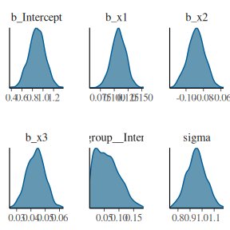

```r
result_hbcc$plots$dens
```

The **autocorrelation plot (ACF)** (`result_hbcc$plots$acf`) visualizes the correlation between samples at different lags. High autocorrelation can indicate inefficient sampling, while rapid decay in autocorrelation across lags suggests that the chains are generating nearly independent samples.

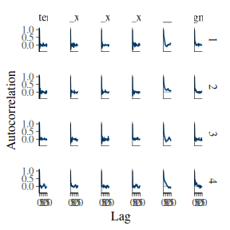

```r
result_hbcc$plots$acf
```

The **NUTS energy plot** (`result_hbcc$plots$nuts_energy`) is specific to models fitted using the No-U-Turn Sampler (NUTS). This plot examines the distribution of the Hamiltonian energy and its changes between iterations. A well-behaved energy plot indicates stable dynamics and efficient exploration of the parameter space.

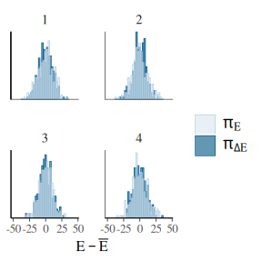

```r
result_hbcc$plots$nuts_energy
```

The **Rhat plot** (`result_hbcc$plots$rhat`) presents the potential scale reduction factor (R̂) for each parameter. R̂ values close to 1.00 (typically < 1.01) are a strong indicator of convergence, showing that the between-chain and within-chain variances are consistent.

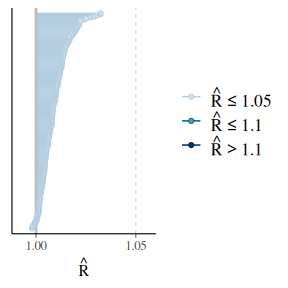

```r
result_hbcc$plots$rhat
```

The **effective sample size (n_eff) plot** (`result_hbcc$plots$neff`) reports how many effectively independent samples have been drawn for each parameter. Higher effective sample sizes are desirable, as they indicate that the posterior estimates are based on a substantial amount of independent information, even if the chains themselves are autocorrelated.

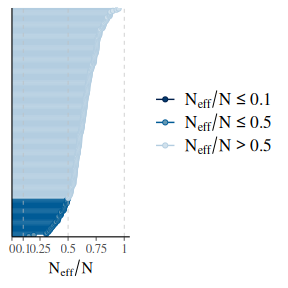

```r
result_hbcc$plots$neff
```

## Model Comparison

The `hbmc` function is used to compare Bayesian hierarchical models and assess their posterior predictive performance. It allows for model comparison, posterior predictive checks, and additional diagnostic visualizations.

```r
result_hbmc <- hbmc(
      model = list(model),
      comparison_metrics = c("loo", "waic", "bf"),
      run_prior_sensitivity= TRUE,
      sensitivity_vars = c("b_Intercept", "b_x1")
  )
```

[figure not shown]

[figure not shown]

[output not shown]

```
#>
#> ------------------- Parameter Plot -------------------
#> Parameter plots for primary model stored in
#> '$primary_model_diagnostics$params_plot'.
```

```
#>
#> =============== Model Comparison Results ================
#> Model comparison metrics was not run or no results are available.
#>
#> ========== Prior Sensitivity Analysis Results ===========
#>
#> --- Prior Sensitivity Analysis Summary ---
#>
#>
#> - For model 'model1':
#>
#>   > Sensitivity result:
#> Sensitivity based on cjs_dist
#> Prior selection: all priors
#> Likelihood selection: all data
#>
#>     variable prior likelihood diagnosis
#>  b_Intercept 0.007      0.114         -
#>         b_x1 0.016      0.177         -
#>
#>   > Plot:
```

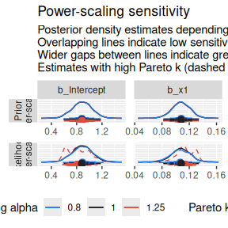

```
#>   Plot may appear in a separate graphics window.
```

```r
result_hbmc$primary_model_diagnostics$pp_check_plot
```

[output not shown]

The **marginal posterior distributions plot** (`result_hbmc$primary_model_diagnostics$params_plot`) displays the estimated distributions of the model parameters based on the posterior samples. This plot is useful for interpreting the uncertainty and central tendency of each parameter. Peaks in the distribution indicate likely values, while wider distributions suggest greater uncertainty.

[figure not shown]

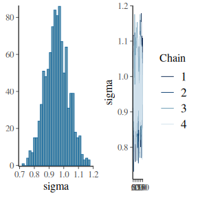

```r
result_hbmc$primary_model_diagnostics$params_plot
```

## Small Area Estimation Predictions

The `hbsae()` function implements Hierarchical Bayesian Small Area Estimation (HBSAE**)** using the `brms` package. It generates small area estimates while accounting for uncertainty and hierarchical structure in the data. The function calculates Mean Predictions, Relative Standard Error (RSE), Mean Squared Error (MSE), and Root Mean Squared Error (RMSE) based on the posterior predictive sample from the fitted Bayesian model.

```r
result_hbsae <- hbsae(model)
summary(result_hbsae)
```

```
#>
#> =============== Summary of hbsae Prediction ===============
#>
#> >> Model Performance Metrics (based on provided data for prediction)
#> Mean RSE (%) of Predictions: 8.4
#> Mean MSE of Predictions: 0.1
#>
#> =================== Prediction Table =====================
#> Access the full data frame with $result_table
#> The table below (in the next console output) shows the model results summary.
#> Dimensions: 100 rows x 4 columns.
#> Columns: Prediction, Actual, RSE_percent, MSE.
#>     Prediction     Actual RSE_percent        MSE
#> 1     5.141828  4.8778119    8.266590 0.18067080
#> 2     3.677523  3.4296960    7.653577 0.07922089
```

[output cut: 98 more lines]

## Conclusion

The hbm function in the hbsaems package offers a comprehensive framework for Small Area Estimation hierarchical Bayesian modeling. It supports flexible model specifications, advanced handling of missing data, and integrates well with diagnostic and comparison tools such as hbcc, hbmc, and hbsae.